# Laboratorio 2 IN5602 - Semestre Otoño 2021

Nicolás Acevedo, Constanza Bastías y Pablo Ubilla

14 de abril de 2021

# Machine Learning

Modelos que puedan automáticamente aprender sobre conjuntos de datos y su forma funcional. Se puede utiliar un conjunto determinado de características para entrenar un algoritmo y extraer información. Estos algoritmos pueden clasificarse según la cantidad y el tipo de supervisión durante el entrenamiento. Los dos tipos principales en los que se enfoca el curso son:

1. Learners supervisados: construyen modelos predictivos.
2. Learners no supervisados: construyen modelos descriptivos.

**¿Cuándo usar ML?**

1. Foco en el pronóstico y no en el entendimiento de las relaciones de las variables.
2. Cuando existen relaciones complejas y no lineales.
3. Base de datos “grandes”

## Aprendizaje supervisado

El algoritmo intenta modelar las relaciones entre la variable objetivo (variable que se predice, $Y$) y los atributos (variables predictoras, $X's$). Por ejemplo: usar los atributos de una casa ($X's$) para predecir el precio de venta ($Y$)

La mayoría de los problemas de aprendizaje supervisado pueden agruparse en regresión o clasificación.

1. Cuando el objetivo es predecir un resultado numérico, nos referimos a un problema de regresión (no debe confundirse con el modelo de regresión lineal).
2. Cuando el objetivo es predecir un resultado categórico, nos referimos a un problema de clasificación.

## Aprendizaje sin supervisión

El objetivo es describir los datos, pero a el análisis se realiza sin una variable objetivo ($Y$). El aprendizaje no supervisado se ocupa de identificar grupos en un conjunto de datos. Los grupos pueden estar definidos por las unidades (clustering) o por las características.

## División de los datos

Para dividir los datos podemos usar muestreo aleatorio (Por lo general, se divide haciendo “80-20”o “70-30”)

- Data train: Estos datos se utilizan para desarrollar conjuntos de características, entrenar el algoritmo, comparar modelos.
- Data test: Estos datos se utilizan para estimar una evaluación imparcial del rendimiento del modelo.

# Desarollo del laboratorio

## Enunciado

Se tiene información sobre ventas de propiedades en EE.UU y se requiere utilizar los atributos de estas propiedades para predecir el precio de venta de la vivienda.

- Tipo de problema: regresión supervisada ($Y$ es númerico)
- Resultado de interés: `Sale_Price` (en dólares)
- Características o variables explicativas $X$: 80
- Observaciones: 2.930

```r
rm(list=ls())                #Limpia todos los objetos creados en R
graphics.off()           #Limpia los gráficos
options(digits = 3)  #Dígitos después del punto para observar (décimas, centésimas,...)
set.seed(12345)      #Fijar semilla de aleatoriedad
# setwd("C:/Users/color/Downloads/Marketing/LAB2_IN5602") #Fijar directorio de preferencia
```

### Paquetes

```r
library(readr)     #Para leer CSV
library(glmnet)    #Para ajustar modelo lineal
library(corrplot)  #Para realizar correlogramas
library(dplyr)     #Para manipulación de datos
library(ggplot2)   #Para gráficos
library(caret)     #Para validar y entrenar los modelos
library(knitr)
```

### Carga de datos

```r
Casas <- read.csv("Casas.csv")
kable(Casas[1:5,1:9]) #kable crea una tabla head(Casas) sirve para visualiar la data
```

| X | MS_SubClass | MS_Zoning | Lot_Frontage | Lot_Area | Street | Alley | Lot_Shape | Land_Contour |
| --- | --- | --- | --- | --- | --- | --- | --- | --- |
| 1 | One_Story_1946_and_Newer_All_Styles | Residential_Low_Density | 141 | 31770 | Pave | No_Alley_Access | Slightly_Irregular | Lvl |
| 2 | One_Story_1946_and_Newer_All_Styles | Residential_High_Density | 80 | 11622 | Pave | No_Alley_Access | Regular | Lvl |
| 3 | One_Story_1946_and_Newer_All_Styles | Residential_Low_Density | 81 | 14267 | Pave | No_Alley_Access | Slightly_Irregular | Lvl |
| 4 | One_Story_1946_and_Newer_All_Styles | Residential_Low_Density | 93 | 11160 | Pave | No_Alley_Access | Regular | Lvl |
| 5 | Two_Story_1946_and_Newer | Residential_Low_Density | 74 | 13830 | Pave | No_Alley_Access | Slightly_Irregular | Lvl |

### División de los datos

Vamos a escoger 70% entrenamiento y 30% para testeo:

```r
# Construimos un vector que esta formado por números de filas aleatoriamente
index <- sample(1:nrow(Casas), size= nrow(Casas)*0.7)
# Base de entrenamiento: del total de datos, tomamos las filas aletorizadas que tienen datos en index
train <- Casas[index, ]
# Anteponiendo el "-" escogemos las filas en de la base que no están en index
test  <- Casas[-index, ]
```

### EDA

Antes de entrenar un modelo predictivo, o incluso antes de realizar cualquier cálculo con un nuevo conjunto de datos, es muy importante realizar una exploración descriptiva de los mismos. Este proceso permite entender mejor que información contiene cada variable, así como detectar posibles errores.

#### Variable de interés

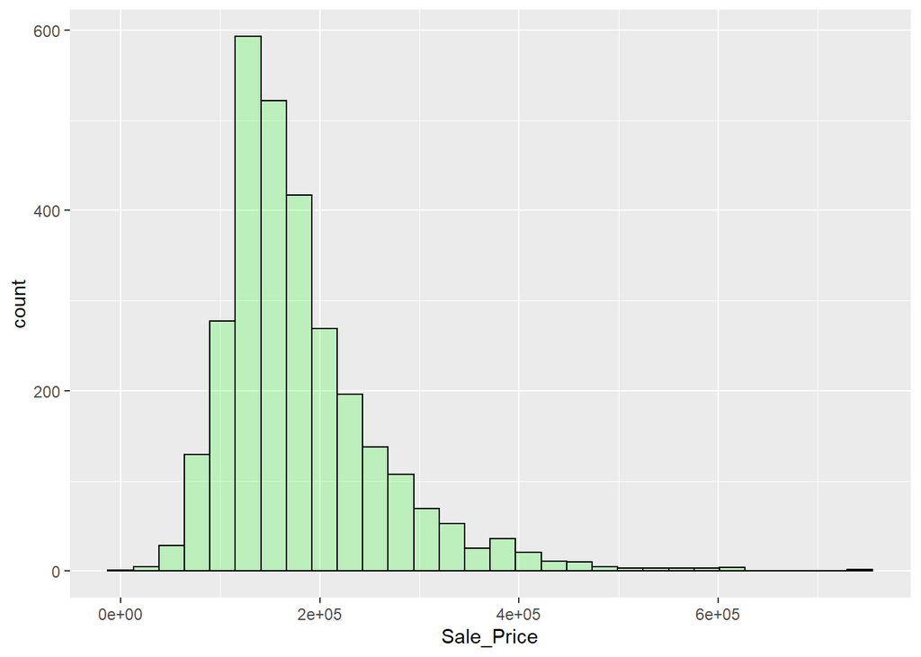

```r
ggplot(data=Casas)+ #Se define un gráfico con ggplot()
  aes(x=Sale_Price)+ #Solo le ingresamos el eje "x" para un histograma
  geom_histogram(col="black", fill="green", alpha = 0.2) # Se define la forma del gráfico. "col" pinta el contorno, "fill" el entorno y "alpha" entrega transparencia
```

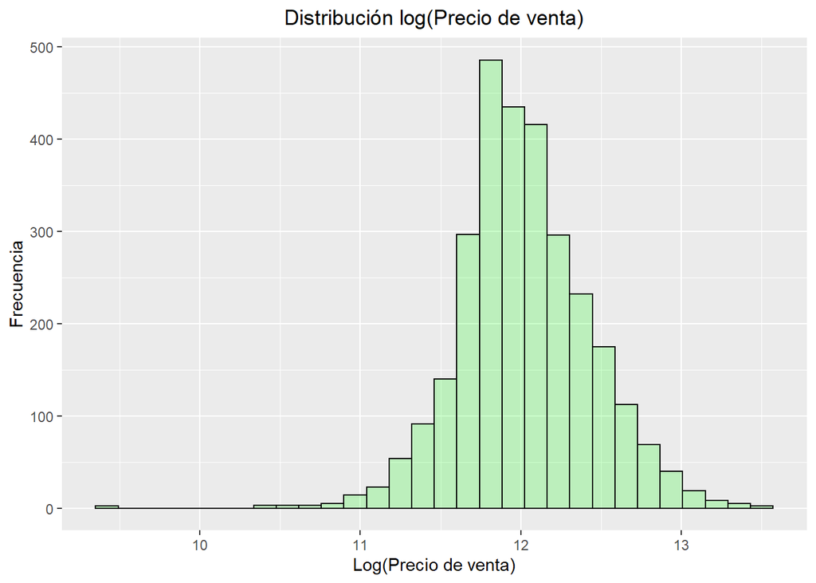

```r
ggplot(data=Casas)+
  aes(x=log(Sale_Price))+
  geom_histogram(col="black", fill="green", alpha=0.2)+
  xlab("Log(Precio de venta)")+ #Etiqueta para el eje x
  ylab("Frecuencia")+ #Etiqueta para el eje y
  ggtitle("Distribución log(Precio de venta)")+ #Título del gráfico
  theme(plot.title = element_text(hjust = 0.5)) #centra el título en el gráfico. Lo ajusta en la posición horizontal (hjust = 0.5)
```

#### Variables explicativas

Escogemos algunas variables: `Year_Built` (Año en que se construyó la casa), `Roof_Style` (Tipo de techo), `Gr_Liv_Area` (espacio habitable total sobre el suelo de una casa) y `Heating_QC`(Calidad y estado de la calefacción)

```r
#R no siempre interpreta bien la naturaleza de las variables: Roof_Style y Heating_QC son factores, pero están como character(string)

#en train
train$Roof_Style=as.factor(train$Roof_Style)
train$Heating_QC=as.factor(train$Heating_QC)
#en test
test$Roof_Style=as.factor(test$Roof_Style)
test$Heating_QC=as.factor(test$Heating_QC)
```

##### `Year_Built`

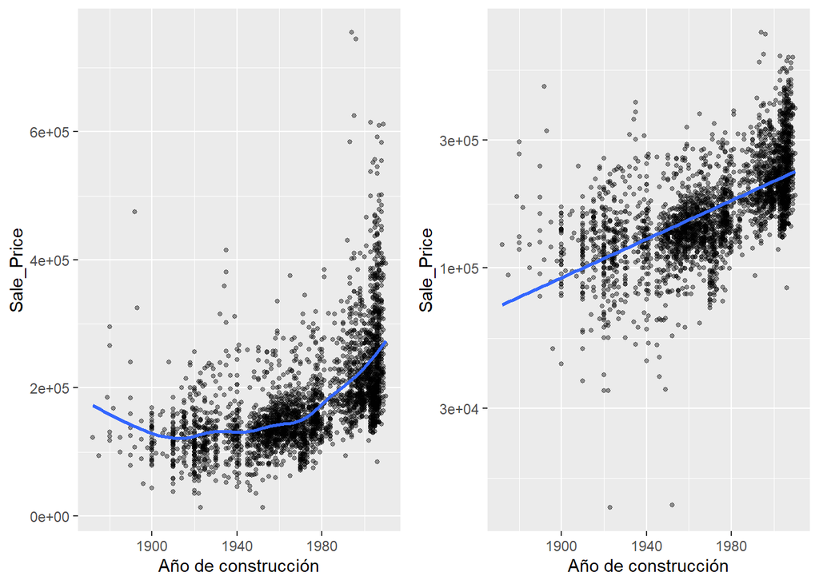

```r
library(gridExtra) #Para unir gráficas
g1 <- ggplot(Casas) +
  aes(x=Year_Built, y=Sale_Price) +
  geom_point(size=1, alpha=0.4) + #"size" aumenta el tamaño de los puntos, "alpha" da transparencia
  geom_smooth(se=FALSE) + #Agregamos un ajuste no lineal sobre los puntos. "se" integra errores estándares
  xlab("Año de construcción")


g2 <- ggplot(Casas) +
  aes(x=Year_Built, y=Sale_Price) +
  geom_point(size = 1, alpha = .4) +
  geom_smooth(method = "lm", se = FALSE) + #Agregamos un ajuste lineal sobre los puntos.
  scale_y_log10() + # "scale_y_log10" transforma el eje "y" a logaritmo.
  xlab("Año de construcción")

grid.arrange(g1, g2, nrow = 1) #une las  gráficas.
```

##### `Gr_Liv_Area` según `Heating_QC`

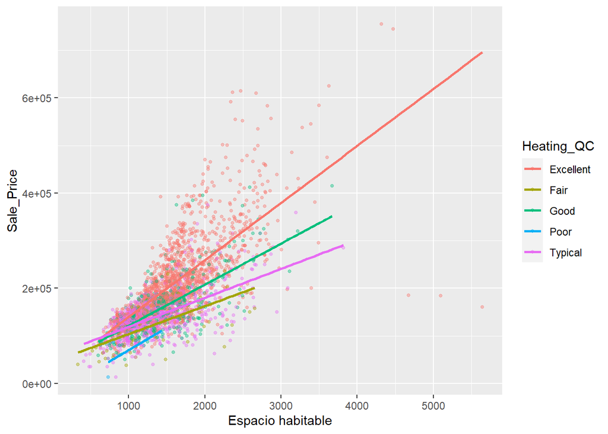

```r
ggplot(Casas) +
  aes(x=Gr_Liv_Area, y=Sale_Price, col=Heating_QC)+ #Se agrega una dimensión de colores "col".
  geom_point(size=1, alpha=0.4) +
  geom_smooth(se=FALSE, method="lm") +
  xlab("Espacio habitable")
```

##### `Roof_Style`

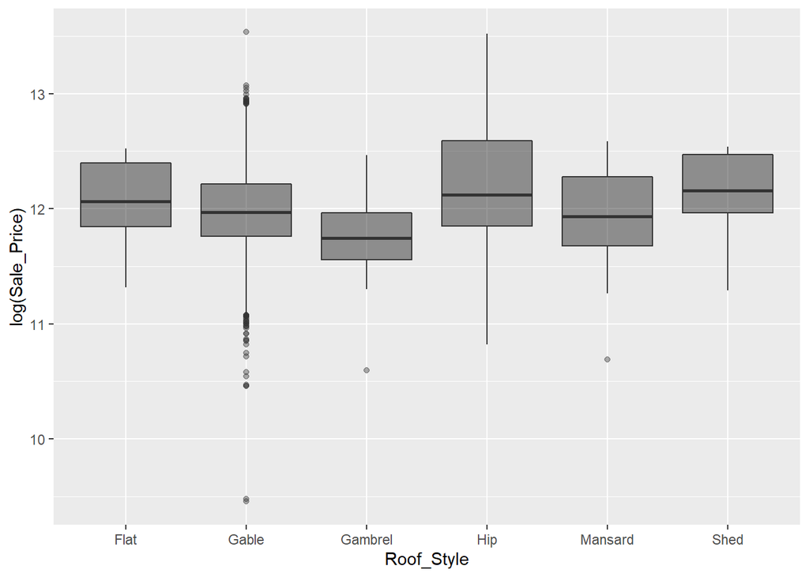

```r
ggplot(Casas) +
  aes(x=Roof_Style, y=log(Sale_Price)) +
  geom_boxplot(alpha=0.4, fill="black") #cambiamos el tipo de gráfico
```

## Regresión Lineal

```r
train.lm <- train(form = Sale_Price ~ Year_Built+Gr_Liv_Area+Roof_Style+Heating_QC, #Fórmula
  data = train, #Datos
  method = "lm", #Algoritmo
  trControl = trainControl(method = "cv", number = 5) #Method = cross validation, number=10 (k-fold)
)

test.lm  <- predict(train.lm , newdata=test) #Vector de datos predichos. Recibe una base de datos (newdata) y un modelo entrenado (train.lm)
error.lm <- test$Sale_Price-test.lm #Calcular los errores de predicción (dato real - dato estimado)
```

## MARS

Este algoritmo no asume una forma funcional de los datos, toma las variables $X$ y trata de “formar” funciones no lineales e interacciones que se ajusten a los datos. Las no linealidades e interacciones se van “ajustando” a una función escalonada o por tramos donde el objetivo es encontrar puntos de cortes o “knots” que se adecuan de mejor forma a los datos. Luego de haber de encontrado muchos “knots”, el algoritmo realiza una “limpieza” donde se eliminan puntos que no contribuyen significativamente a la precisión predictiva (redundantes). Este proceso se le llama poda.

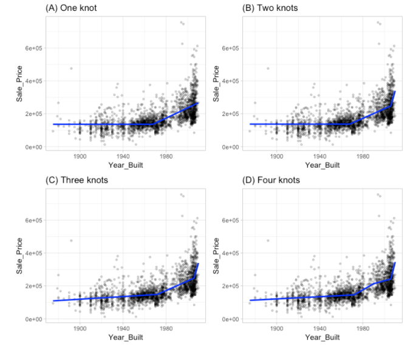

```r
#Ejecutar MARS (Multivariate adaptive regression spline)
train.mars <- train(form = Sale_Price ~ Year_Built+Gr_Liv_Area+Roof_Style+Heating_QC,
                    data=train,
                    method="earth", #MARS
                    trControl = trainControl("cv", number=5),
                    preProcess = c("center","scale"), #Pre-procesa datos. "center" resta el promedio de las variables, "scale" las divide por la desviación estandar. Esto ayuda para el tratamiento de outliers.
                    tuneLength = 5 #Indica que pruebe diferentes valores por default para el parámetro principal
)
print(train.mars)
```

```
## Multivariate Adaptive Regression Spline
##
## 2051 samples
##    4 predictor
##
## Pre-processing: centered (11), scaled (11)
## Resampling: Cross-Validated (5 fold)
## Summary of sample sizes: 1641, 1641, 1642, 1639, 1641
## Resampling results across tuning parameters:
##
##   nprune  RMSE   Rsquared  MAE
##   2       56457  0.508     38925
##   3       47455  0.653     32511
##   5       47031  0.666     30742
##   6       45222  0.690     29631
##   8       44632  0.698     29577
##
## Tuning parameter 'degree' was held constant at a value of 1
## RMSE was used to select the optimal model using the smallest value.
## The final values used for the model were nprune = 8 and degree = 1.
```

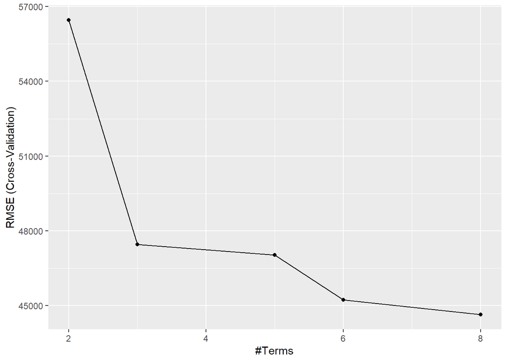

```r
ggplot(train.mars)
```

```r
test.mars  <- predict(train.mars, newdata=test) #Vector de datos predichos
error.mars <- test$Sale_Price-test.mars #(dato real - dato estimado)
```

## K-Nearest Neighbors

Es un algoritmo en el que cada observación se predice en función de su “similitud” con otras observaciones y luego usa el valor de respuesta media de k observaciones como el resultado previsto. Para medir “similitud” usamos métricas (distancias) en el espacio $\mathcal{R}^j$. Para dos observaciones $i$ y $n$, $J$ predictores, tenemos la métricas:

$$\sqrt{\sum_{j=1}^J (X_{ij}-X_{nj})^2} \hspace{.5 cm} \text{(Métrica Eucliadiana)}$$

$$\sum_{j=1}^J |X_{ij}-X_{nj}| \hspace{.5 cm} \text{(Métrica Manhattan)}$$

$$\left(\sum_{j=1}^J |X_{ij}-X_{nj}|^{p}\right)^{1/p} \hspace{.5 cm} \text{(Métrica Minkowski)}$$
Al encontrar los k-vecinos más cercanos, ponderamos sus resultados ($Y$):

$$\hat{Y}_i=w_1Y_{1,i}+...+w_kY_{k,i}$$

Si utilizamos ponderaciones $w_k$ que no son iguales (ese caso es $w_k=1/k$), puntos cercanos deberían pesar más que puntos lejanos.

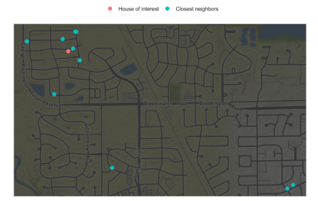

```r
### Ejecutar KNN
train.knn <- train(Sale_Price ~ Year_Built+Gr_Liv_Area+Roof_Style+Heating_QC,
                   data=train, method="knn",
                   trControl = trainControl("cv", number=5),
                   preProcess = c("center","scale"),
                   tuneLength = 5
)

print(train.knn)
```

```
## k-Nearest Neighbors
##
## 2051 samples
##    4 predictor
##
## Pre-processing: centered (11), scaled (11)
## Resampling: Cross-Validated (5 fold)
## Summary of sample sizes: 1639, 1642, 1641, 1641, 1641
## Resampling results across tuning parameters:
##
##   k   RMSE   Rsquared  MAE
##    5  41606  0.737     27524
##    7  41355  0.737     27230
##    9  40698  0.746     26965
##   11  40571  0.747     26790
##   13  40758  0.744     26969
##
## RMSE was used to select the optimal model using the smallest value.
## The final value used for the model was k = 11.
```

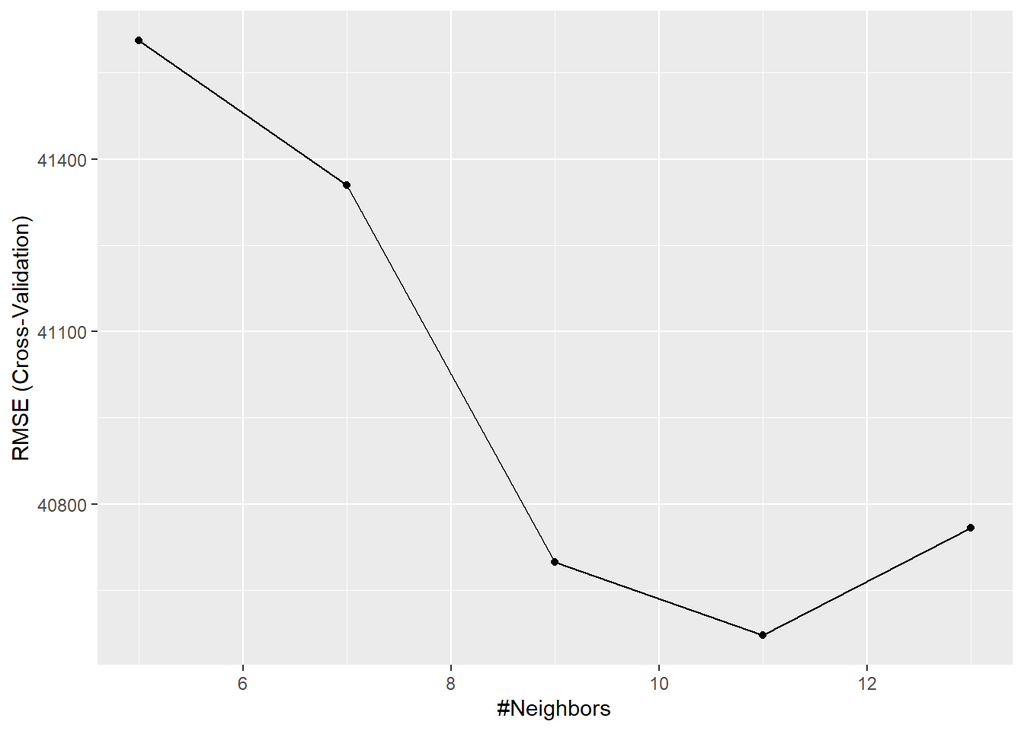

```r
ggplot(train.knn)
```

```r
test.knn  <- predict(train.knn, newdata=test)
error.knn <- test$Sale_Price-test.knn
```

## CART

Modelo basado en árboles de regresión - algoritmo no paramétrico - se utiliza cuando hay múltiples regresores. Divide el espacio de las características ($X$) según particiones binarias dada alguna regla de condición. De esto van resultando regiones más pequeñas.

El objetivo en cada nodo es encontrar la “mejor” característica ($X_j$) para dividir los datos restantes en una de dos regiones ($R_1$ y $R_2$) de manera que el error general entre la respuesta real ($Y$) y la constante predicha ($c$) se minimiza. Para problemas de regresión, la función objetivo a minimizar es el $SSE$ (suma de cuadrados residuales) total.

$$SSE=\sum_{i\in R_1} (y_i-c_1)^2 + \sum_{i\in R_2} (y_i-c_2)^2$$

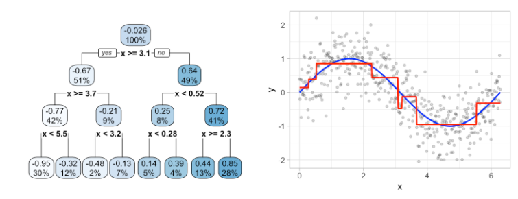

```r
### Ejecutar CART (Classification and Regression Trees)
train.cart <- train(Sale_Price ~ Year_Built+Gr_Liv_Area+Roof_Style+Heating_QC,
                    data=train, method="rpart2",
                    trControl = trainControl("cv", number=5),
                    preProcess = c("center","scale"),
                    tuneLength = 5
)
print(train.cart)
```

```
## CART
##
## 2051 samples
##    4 predictor
##
## Pre-processing: centered (11), scaled (11)
## Resampling: Cross-Validated (5 fold)
## Summary of sample sizes: 1641, 1641, 1641, 1640, 1641
## Resampling results across tuning parameters:
##
##   maxdepth  RMSE   Rsquared  MAE
##   1         64280  0.362     44313
##   2         55602  0.527     38800
##   3         54264  0.550     38025
##   4         52028  0.587     36498
##   5         46730  0.668     32660
##
## RMSE was used to select the optimal model using the smallest value.
## The final value used for the model was maxdepth = 5.
```

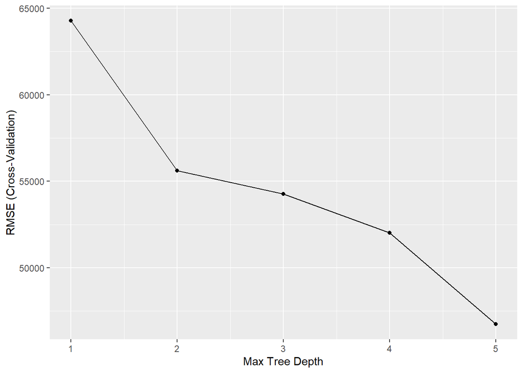

```r
ggplot(train.cart)
```

```r
test.cart  <- predict(train.cart, newdata=test)
error.cart <- test$Sale_Price-test.cart
```

## Random Forest

Random Forest se construye utilizando los principios fundamentales de los árboles de regresión y el bagging. Este úlimo, genera múltiples muestras de los datos y las agrega a los múltiples árboles de regresión. Pero al construir estos árboles de decisión se debe elegir una muestra aleatoria de predictores$X$ (llamados $mtry$).Esta agregación reduce la variación del procedimiento general y da como resultado un mejor rendimiento predictivo.

```r
### Ejecutar Random Forest
train.randomf <- train(Sale_Price ~ Year_Built+Gr_Liv_Area+Roof_Style+Heating_QC,
                       data=train, method="rf",
                       trControl = trainControl("cv", number=5),
                       preProcess = c("center","scale"),
                       tuneLength = 5
)
print(train.randomf)
```

```
## Random Forest
##
## 2051 samples
##    4 predictor
##
## Pre-processing: centered (11), scaled (11)
## Resampling: Cross-Validated (5 fold)
## Summary of sample sizes: 1641, 1640, 1641, 1641, 1641
## Resampling results across tuning parameters:
##
##   mtry  RMSE   Rsquared  MAE
##    2    48138  0.706     32177
##    4    40339  0.756     26781
##    6    38848  0.767     25656
##    8    39065  0.764     25935
##   11    39689  0.757     26369
##
## RMSE was used to select the optimal model using the smallest value.
## The final value used for the model was mtry = 6.
```

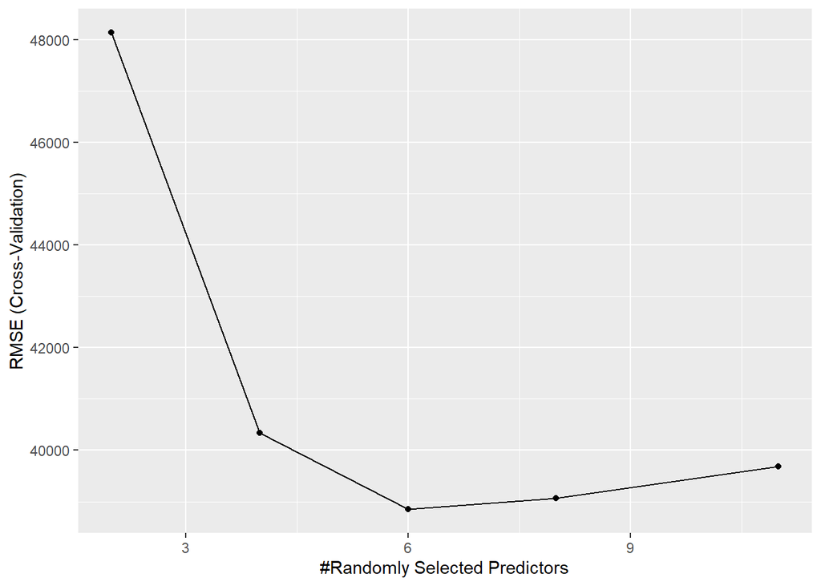

```r
ggplot(train.randomf)
```

```r
test.randomf  <- predict(train.randomf, newdata=test)
error.randomf <- test$Sale_Price-test.randomf
```

## Comparación de modelos

```r
sales.test <- data.frame(lm=test.lm, mars=unname(test.mars),  knn=test.knn,  cart=test.cart,  rf=test.randomf, sales=test$Sale_Price)
error.test <- data.frame(lm=error.lm, mars=unname(error.mars), knn=error.knn, cart=error.cart, rf=error.randomf)

summary(abs(error.test))
```

```
##        lm              mars             knn              cart
##  Min.   :    31   Min.   :   133   Min.   :     9   Min.   :    13
##  1st Qu.:  9891   1st Qu.: 10146   1st Qu.:  8000   1st Qu.: 10387
##  Median : 22802   Median : 21413   Median : 19077   Median : 23566
##  Mean   : 30386   Mean   : 28767   Mean   : 27700   Mean   : 32816
##  3rd Qu.: 40731   3rd Qu.: 37686   3rd Qu.: 36841   3rd Qu.: 43279
##  Max.   :475711   Max.   :444038   Max.   :306721   Max.   :276079
##        rf
##  Min.   :    47
##  1st Qu.:  7455
##  Median : 17461
##  Mean   : 25058
##  3rd Qu.: 33158
##  Max.   :279300
```

```r
summary(error.test)
```

```
##        lm               mars              knn               cart
##  Min.   :-475711   Min.   :-444038   Min.   :-306721   Min.   :-235019
##  1st Qu.: -26428   1st Qu.: -24660   1st Qu.: -23082   1st Qu.: -30352
##  Median :  -3344   Median :  -2154   Median :  -3282   Median :  -4574
##  Mean   :  -3070   Mean   :  -2542   Mean   :  -2287   Mean   :  -3593
##  3rd Qu.:  18394   3rd Qu.:  18052   3rd Qu.:  14475   3rd Qu.:  18398
##  Max.   : 212784   Max.   : 207689   Max.   : 258964   Max.   : 276079
##        rf
##  Min.   :-279300
##  1st Qu.: -21392
##  Median :  -4189
##  Mean   :  -2688
##  3rd Qu.:  11949
##  Max.   : 193366
```

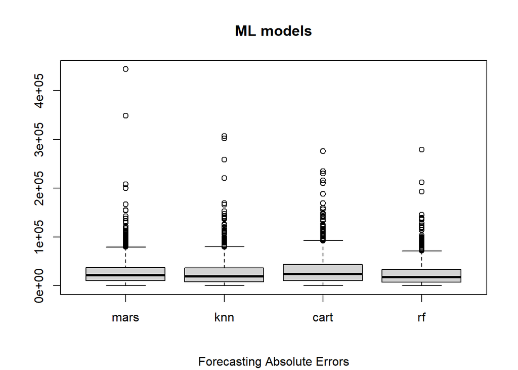

```r
boxplot(abs(subset(error.test, select=-lm))); title(main="ML models", sub="Forecasting Absolute Errors")
```

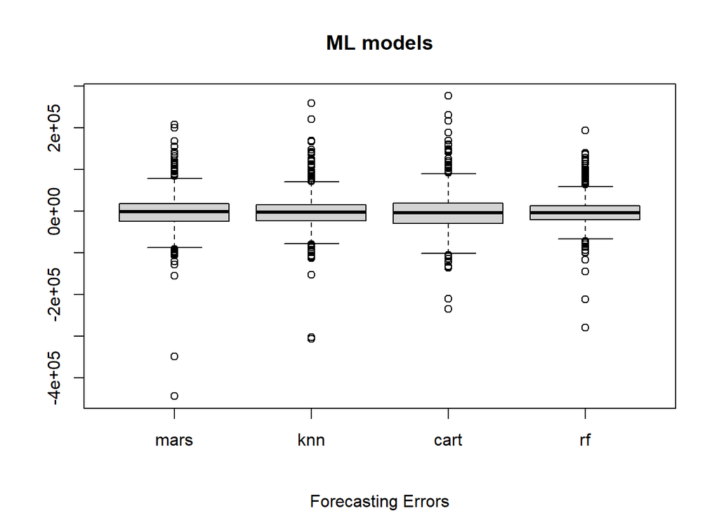

```r
boxplot(subset(error.test, select=-lm)); title(main="ML models", sub="Forecasting Errors")
```

## Preguntas

### Pregunta 1

Para esta pregunta se escogen atributos 10 (variables explicativas) que puedan ser predictoras del precio de las casa. Se escogen entonces *Street, Lot_Shape, Exter_Cond, Central_Air, Garage_Area, Kitchen_Qual, Year_Built, Gr_Liv_Area, Roof_Style* y *Heating_QC*.

¿ Por qué podrían ser útiles *Garage_Area, Kitchen_Qual* y *Exter_Cond*?

- *Garage_Area*: El sólo hecho de que una casa cuente con un garage suele implicar que la casa tenga un alto precio. Es necesario que esta sea de un tamaño considerable (en la mayoría de los casos en USA) para contar con un garage. En cuanto al área de este, mientras mayor es, significa que tiene capacidad para más vehículos (u otros objetos), lo que implica que la casa también debe ser mayor para poder dar el paso a un garage de mayor tamaño. Dicho esto, es esperable que a mayor área de garage, el precio de las casas sea mayor.
- *Kitchen_Qual*: *Este atributo es similar al anterior en el sentido de que una mayor calidad en la cocina implica que está apuntando a personas de mayores recursos, no a personas que sólo buscan una casa con cocina funcional, por lo que puede esperarce que a mayor calidad en la cocina, mayor sea el precio de la casa.*
- *Exter_Cond*: Si la condición actual de la parte exterior de la casa no es óptima, es esperable que los precios de las casas sean menores, mientras que en una condición óptima sean mayores, ya que está directamente relacioando con la calidad de lo que se está comprando y no se pagarán precios altos por algo de mala calidad.

```r
# Construcción de la sub-base

Casas <- Casas[,c("Sale_Price", "Street", "Lot_Shape", "Exter_Cond", "Central_Air", "Garage_Area", "Kitchen_Qual", "Year_Built", "Gr_Liv_Area", "Roof_Style", "Heating_QC")]

# Para evitar problemas pasamos los atributos de tipo
# categóricos a factores
for (col in colnames(Casas)){
  # Si no forma parte de los numéricos
  if (!col %in% c("Garage_Area", "Gr_Liv_Area", "Year_Built")){
    Casas[[col]] <- as.factor(Casas[[col]])
  }
}

# Pasamos la variable dependiente (Sales Prices) a numerica
Casas$Sale_Price = as.numeric(Casas$Sale_Price)

# Tampoco tiene sentido el año numéricamente, pero son demasiados factores para analizarlo como tal. Por ende, vamos a transformar este atrbibuto a la distancia entre el último año en la base con la columna en cuestión, con lo que tendremos una diferencia de años que sí tiene sentido numéricamente para comparar
Casas$Year_Built <- max(Casas$Year_Built) - Casas$Year_Built

# Vemos las descripciones de los atributos
str(Casas)
```

```
## 'data.frame':    2930 obs. of  11 variables:
##  $ Sale_Price  : num  635 139 451 724 538 561 630 544 704 536 ...
##  $ Street      : Factor w/ 2 levels "Grvl","Pave": 2 2 2 2 2 2 2 2 2 2 ...
##  $ Lot_Shape   : Factor w/ 4 levels "Irregular","Moderately_Irregular",..: 4 3 4 3 4 4 3 4 4 3 ...
##  $ Exter_Cond  : Factor w/ 5 levels "Excellent","Fair",..: 5 5 5 5 5 5 5 5 5 5 ...
##  $ Central_Air : Factor w/ 2 levels "N","Y": 2 2 2 2 2 2 2 2 2 2 ...
##  $ Garage_Area : int  528 730 312 522 482 470 582 506 608 442 ...
##  $ Kitchen_Qual: Factor w/ 5 levels "Excellent","Fair",..: 5 5 3 1 5 3 3 3 3 3 ...
##  $ Year_Built  : int  50 49 52 42 13 12 9 18 15 11 ...
##  $ Gr_Liv_Area : int  1656 896 1329 2110 1629 1604 1338 1280 1616 1804 ...
##  $ Roof_Style  : Factor w/ 6 levels "Flat","Gable",..: 4 2 4 4 2 2 2 2 2 2 ...
##  $ Heating_QC  : Factor w/ 5 levels "Excellent","Fair",..: 2 5 5 1 3 1 1 1 1 3 ...
```

```r
# samples aleatorio
index <- sample(1:nrow(Casas), size= nrow(Casas)*0.7)

# entrenamiento 70%
train <- Casas[index, ]
# test 30%
test  <- Casas[-index, ]
```

### Pregunta 2

A continuación se emplean 3 modelos de predicción: regresión lineal, knn y random forest. Para estos se utiliza una base de entrenamiento con el 70% de la base de datos, con las que se obtendrán los parámetros de los modelos para posteriormente realizar una predicción del precio de venta sobre la base de testeo (30% de los datos).

##### Regresión Lineal

```r
#Corra 1 modelo de regresión lineal y 2 modelos de Machine Learning vistos en la clase con la base de datos reducida,  para predecir el precio de las casas.

train.lm <- train(form = Sale_Price ~ ., #Fórmula
  data = train, #Datos
  method = "lm", #Algoritmo
  trControl = trainControl(method = "cv", number = 5) #Method = cross validation, number=10 (k-fold)
)
print(train.lm)
```

```
## Linear Regression
##
## 2051 samples
##   10 predictor
##
## No pre-processing
## Resampling: Cross-Validated (5 fold)
## Summary of sample sizes: 1641, 1640, 1641, 1642, 1640
## Resampling results:
##
##   RMSE  Rsquared  MAE
##   115   0.795     82.6
##
## Tuning parameter 'intercept' was held constant at a value of TRUE
```

```r
test.lm  <- predict(train.lm, newdata=test)
error.lm <- test$Sale_Price-test.lm
```

##### KNN

```r
### Ejecutar KNN
train.knn <- train(Sale_Price ~ .,
                   data=train, method="knn",
                   trControl = trainControl("cv", number=5),
                   preProcess = c("center","scale"),
                   tuneLength = 5
)
print(train.knn)
```

```
## k-Nearest Neighbors
##
## 2051 samples
##   10 predictor
##
## Pre-processing: centered (25), scaled (25)
## Resampling: Cross-Validated (5 fold)
## Summary of sample sizes: 1639, 1640, 1642, 1642, 1641
## Resampling results across tuning parameters:
##
##   k   RMSE  Rsquared  MAE
##    5  120   0.773     89.0
##    7  121   0.769     89.3
##    9  121   0.768     89.6
##   11  122   0.763     90.4
##   13  122   0.764     90.6
##
## RMSE was used to select the optimal model using the smallest value.
## The final value used for the model was k = 5.
```

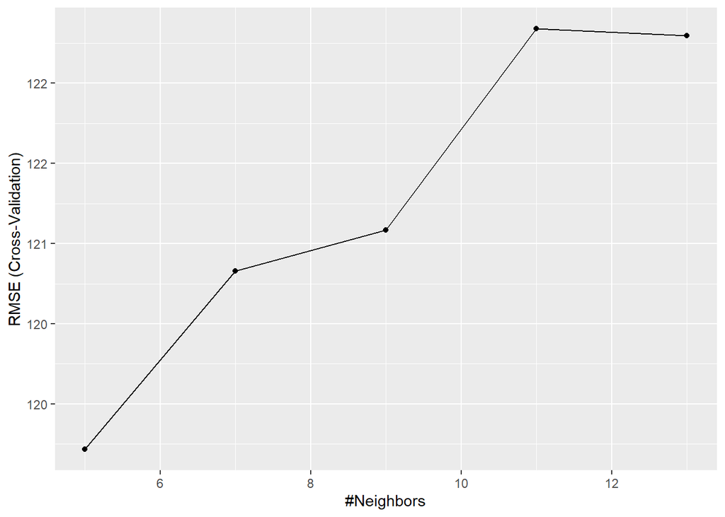

```r
ggplot(train.knn)
```

```r
test.knn  <- predict(train.knn, newdata=test)
error.knn <- test$Sale_Price-test.knn
```

##### Random Forest

```r
### Ejecutar Random Forest
train.randomf <- train(Sale_Price ~ Year_Built+Gr_Liv_Area+Roof_Style+Heating_QC,
                       data=train, method="rf",
                       trControl = trainControl("cv", number=5),
                       preProcess = c("center","scale"),
                       tuneLength = 5
)
print(train.randomf)
```

```
## Random Forest
##
## 2051 samples
##    4 predictor
##
## Pre-processing: centered (11), scaled (11)
## Resampling: Cross-Validated (5 fold)
## Summary of sample sizes: 1641, 1641, 1640, 1641, 1641
## Resampling results across tuning parameters:
##
##   mtry  RMSE  Rsquared  MAE
##    2    143   0.733     115.3
##    4    119   0.782      91.2
##    6    116   0.789      86.2
##    8    117   0.783      86.3
##   11    119   0.776      87.3
##
## RMSE was used to select the optimal model using the smallest value.
## The final value used for the model was mtry = 6.
```

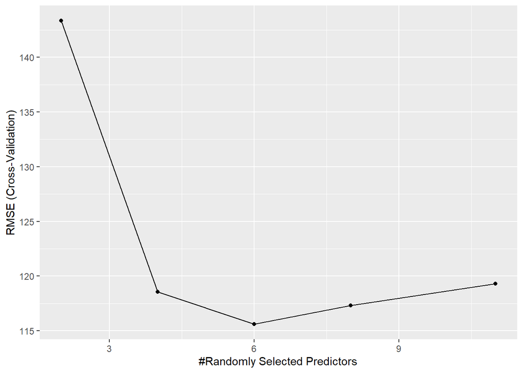

```r
ggplot(train.randomf)
```

```r
test.randomf  <- predict(train.randomf, newdata=test)
error.randomf <- test$Sale_Price-test.randomf
```

### Pregunta 3

```r
# Comparación de Modelos: Compare los modelos a través de métricas presentadas en el laboratorio.
# ¿Cuál es el mejor modelo predictivo?

sales.test <- data.frame(lm=test.lm, knn=test.knn,  rf=test.randomf, sales=test$Sale_Price)
error.test <- data.frame(lm=error.lm, knn=error.knn, rf=error.randomf)

summary(abs(error.test))
```

```
##        lm           knn            rf
##  Min.   :  1   Min.   :  0   Min.   :  0
##  1st Qu.: 29   1st Qu.: 26   1st Qu.: 30
##  Median : 65   Median : 61   Median : 63
##  Mean   : 80   Mean   : 82   Mean   : 84
##  3rd Qu.:110   3rd Qu.:118   3rd Qu.:120
##  Max.   :559   Max.   :510   Max.   :436
```

```r
summary(error.test)
```

```
##        lm            knn             rf
##  Min.   :-559   Min.   :-445   Min.   :-436
##  1st Qu.: -72   1st Qu.: -66   1st Qu.: -69
##  Median : -10   Median :  -6   Median :  -7
##  Mean   :  -6   Mean   :  -3   Mean   :  -2
##  3rd Qu.:  55   3rd Qu.:  54   3rd Qu.:  59
##  Max.   : 468   Max.   : 510   Max.   : 410
```

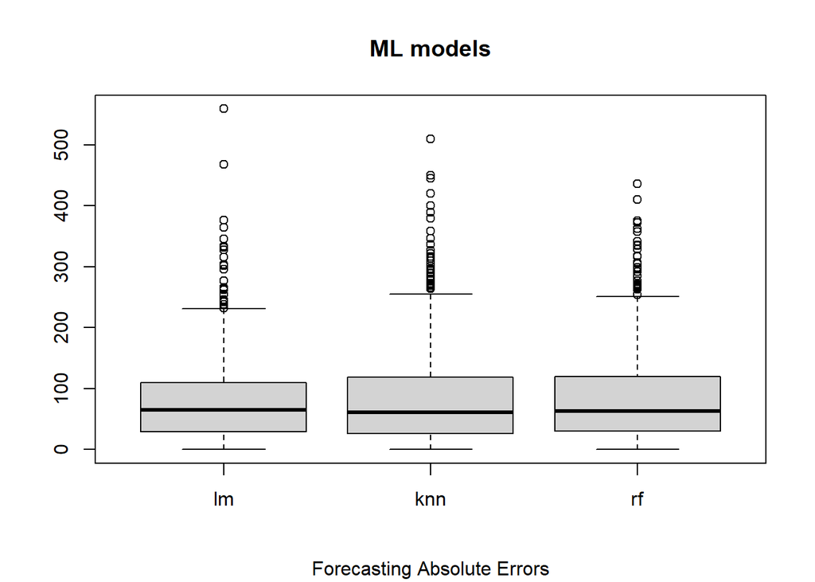

```r
boxplot(abs(subset(error.test))); title(main="ML models", sub="Forecasting Absolute Errors")
```

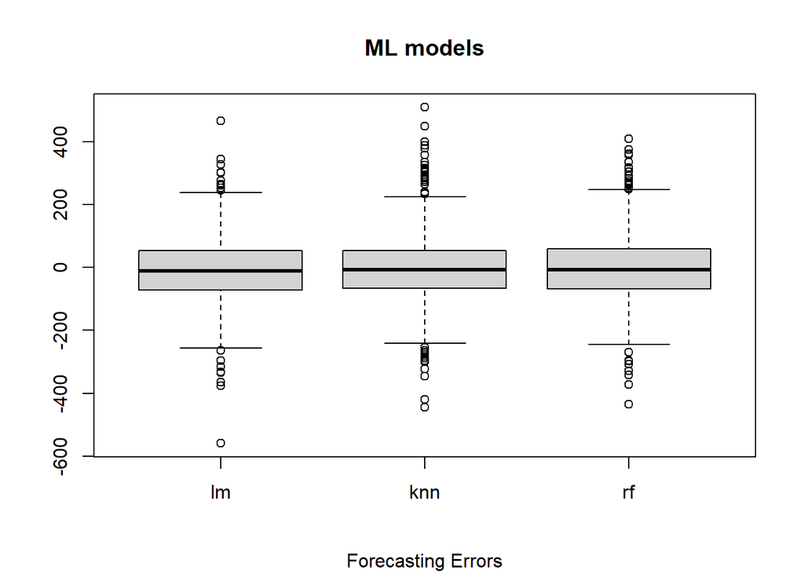

```r
boxplot(subset(error.test)); title(main="ML models", sub="Forecasting Errors")
```

**¿Cuál es el mejor modelo predictivo?**

Observando los errores absolutos se puede observar que si bien todos los valores son relativamente cercanos, el que presenta un menor error es el modelo de regresión lineal simple (MAE = 80), seguido por el modelo KNN (MAE = 82]), siendo el peor, pero **muy poca diferencia**, el random forest (MAE = 84).